# Uganda: SEAS5 drought forecast × humanitarian caseload

Special analysis with country-team JIAF 2.0 Light and response-monitoring data

Published

August 24, 2026

**NoteWhy this document exists**

Uganda has no HNRP. Its only response plan is the refugee RRP, which the Forecast × HNRP pipeline excludes as not the country’s own plan, so Uganda does not appear in the app. This standalone analysis borrows from and adapts the Forecast × HNRP tab’s methodology for Uganda, with supplementary data from the country team:

- PiN and severity: *Uganda JIAF 2.0 Light - Data Collection (v5 census baseline)*, sheets `1. Severity` and `2. PiN` (22 districts × host community / refugee population groups; the raw sheets list 26 “District” values, four of which are subtotal rows the loader drops).
- Targeted and reached: *Gender-MAX Targeted / Achieved People* (2026-08-19), district-level maxima with gender and disability breakdowns.
- Climate: the same SEAS5 / ERA5 sources the app uses. The region level comes straight from the rasterstats DB. The district level was computed for this analysis (Uganda is capped at `max_adm_level=1` in the rasterstats registry), with exactextract over the same COGs; the method reproduces the DB’s region means within about 1%, and the results run through the repo’s unchanged skill and return-period code.

It reads in four steps: where the season stands (observed), where it is heading (the forecast), what that timing means for crops and pasture, and who is exposed, ending in a priority readout. Flooding runs on different timing from the drought, so the flood outlook for the wet Oct-Dec season has its own section at the end.

**setup: imports, thresholds, loaders**

```python
import calendar
import math
import os
import sys
from pathlib import Path

os.environ["TQDM_DISABLE"] = "1"   # tqdm widgets render as opaque bars in HTML
# DuckDB (used by the EM-DAT loader) pops a Jupyter progress widget that
# renders as an opaque bar in the HTML; disable it on every new connection.
import duckdb
_duckdb_connect = duckdb.connect
def _quiet_connect(*args, **kwargs):
    con = _duckdb_connect(*args, **kwargs)
    try:
        con.execute("SET enable_progress_bar = false")
    except duckdb.Error:
        pass
    return con
duckdb.connect = _quiet_connect

import geopandas as gpd
import matplotlib.pyplot as plt
import numpy as np
import ocha_stratus as stratus
import pandas as pd
from matplotlib.colors import ListedColormap
from matplotlib.patches import Patch

REPO = Path.cwd()
if not (REPO / "src").exists():          # rendered from analysis/
    REPO = REPO.parent
sys.path.insert(0, str(REPO))
sys.path.insert(0, str(REPO / "pipeline"))

from src.constants import PROJECT_PREFIX, TRIMESTERS
from src.skill import trimester_lead
from src.datasources import uga_country_team as uct
from export_static_site import (THRESHOLDS, _actual_issued_year, _tri_valid,
                                _tri_label, compute_rainy_set)
from ocha_stratus import codab

UGA_DIR = f"{PROJECT_PREFIX}/processed/uga"

# The app's own palette, so figures read like the Forecast × HNRP tab.
C_DROUGHT_VSEV = "#7f5619"   # strongly below normal (RP >= vsev_rp)
C_DROUGHT_SEV  = "#dda555"   # below normal        (RP >= sev_rp)
C_MUTED        = "#e9eeee"   # no qualifying drought signal
C_EDGE         = "#c4d0d1"
C_PIN, C_TGT, C_REA = "#009EDB", "#F58220", "#D15353"
JIAF_COLORS = ["#e9f2fb", "#d4e5f7", "#82b5e9", "#418fde", "#1f69b3"]

cod1 = codab.load_codab_from_blob("uga", admin_level=1)
cod2 = codab.load_codab_from_blob("uga", admin_level=2)
```

**forecast: worst qualifying drought slot per unit (app logic)**

```python
def worst_drought_slot(skill: pd.DataFrame, rainy_set: set) -> pd.DataFrame:
    """Port of export_hnrp_drought.py's per-unit selection: at the latest
    issuance, among valid (lead -2..4) rainy-season trimesters with skill
    r >= r_mod and a dry-side forecast (percentile < 50), keep the trimester
    with the highest drought return period."""
    # Latest issuance, the app's way: max actual issued year, then max month in it.
    iy = skill[skill["current_forecast_year"].notna()].copy()
    iy["_iy"] = iy.apply(_actual_issued_year, axis=1)
    by_month = iy.groupby("issued_month")["_iy"].max().astype(int)
    issued_year = int(by_month.max())
    issued_month = int(by_month[by_month == issued_year].index.max())
    # Filter on the actual issued YEAR too, never the month alone: if the skill
    # pipeline ran before the current in-season ERA5 month reached the DB, the
    # in-season trimesters at this issued_month still carry LAST year's forecast.
    sub = iy[(iy["issued_month"] == issued_month) & (iy["_iy"] == issued_year)].copy()
    sub = sub[sub.apply(lambda r: _tri_valid(TRIMESTERS[r["trimester"]], issued_month), axis=1)]

    def _mm(r):
        days = sum(calendar.monthrange(2025, m)[1] for m in TRIMESTERS[r["trimester"]])
        fc = round(math.expm1(float(r["current_forecast_mean"])) * days) if pd.notna(r["current_forecast_mean"]) else None
        nrm = round(math.expm1(float(r["era5_mean"])) * days) if pd.notna(r["era5_mean"]) else None
        return fc, nrm

    rows = []
    for pcode, g in sub.groupby("pcode"):
        best, why = None, set()
        for _, r in g.iterrows():
            pct, pr = r["forecast_percentile"], r["pearson_r"]
            if pd.isna(pct) or pd.isna(pr):
                continue
            rainy = (pcode, r["trimester"]) in rainy_set
            if not rainy:
                why.add("off-season"); continue
            if pr < THRESHOLDS["r_mod"]:
                why.add("low skill"); continue
            if pct >= 50:
                why.add("wet/normal"); continue
            if pd.isna(r["forecast_rp"]):
                continue
            if best is None or r["forecast_rp"] > best["drought_rp"]:
                fc_mm, nrm_mm = _mm(r)
                best = dict(trimester=r["trimester"], tri_label=_tri_label(TRIMESTERS[r["trimester"]]),
                            lead=trimester_lead(issued_month, TRIMESTERS[r["trimester"]]),
                            drought_rp=float(r["forecast_rp"]), pct=float(pct), r=float(pr),
                            fc_mm=fc_mm, nrm_mm=nrm_mm)
        row = dict(pcode=pcode, issued_month=issued_month, issued_year=issued_year)
        if best:
            row |= best
            row["cat"] = "strongly below normal" if best["drought_rp"] >= THRESHOLDS["vsev_rp"] \
                else ("below normal" if best["drought_rp"] >= THRESHOLDS["sev_rp"] else "mild dry signal")
        else:
            # no qualifying slot: say why (dominant reason across trimesters)
            row["cat"] = ("no rainy trimester in window" if why == {"off-season"}
                          else " / ".join(sorted(why)) if why else "no data")
        rows.append(row)
    return pd.DataFrame(rows)


def rainy_from_era5(era5: pd.DataFrame) -> set:
    mc = (era5.assign(month=era5["valid_date"].dt.month)
              .groupby(["pcode", "month"])["mean"].mean()
              .reset_index().rename(columns={"mean": "mean_mm_day"}))
    return compute_rainy_set(mc)


# Region level (adm1): straight from the rasterstats DB + app skill parquet.
skill1 = stratus.load_parquet_from_blob(
    f"{PROJECT_PREFIX}/processed/skill_stats_detrended_adm1.parquet", stage="dev")
skill1 = skill1[skill1["iso3"] == "UGA"]
engine = stratus.get_engine(stage="prod")
era5_1 = pd.read_sql(
    "SELECT pcode, valid_date, mean FROM public.era5 WHERE iso3='UGA' AND adm_level=1",
    engine, parse_dates=["valid_date"])
fc1 = worst_drought_slot(skill1, rainy_from_era5(era5_1))

# District level (adm2): computed for this analysis (see callout above).
skill2 = stratus.load_parquet_from_blob(f"{UGA_DIR}/skill_stats_detrended_adm2.parquet", stage="dev")
era5_2 = stratus.load_parquet_from_blob(f"{UGA_DIR}/era5_adm2.parquet", stage="dev")
era5_2["valid_date"] = pd.to_datetime(era5_2["valid_date"])
fc2 = worst_drought_slot(skill2, rainy_from_era5(era5_2))

issued = int(fc2["issued_month"].iloc[0])
issued_yr = int(fc2["issued_year"].iloc[0])
if (issued, issued_yr) != (int(fc1["issued_month"].iloc[0]), int(fc1["issued_year"].iloc[0])):
    raise ValueError(
        f"adm1 and adm2 skill parquets disagree on the latest issuance: "
        f"adm2 {calendar.month_name[issued]} {issued_yr} vs adm1 "
        f"{calendar.month_name[int(fc1['issued_month'].iloc[0])]} {int(fc1['issued_year'].iloc[0])} "
        f"— re-run the stale pipeline before rendering")
print(f"Latest issuance: {calendar.month_name[issued]} {issued_yr} | "
      f"{len(fc2)} districts, {len(fc1)} regions")
```

```
Latest issuance: August 2026 | 135 districts, 4 regions
```

## Where the season stands

The place to start is what has actually fallen. The curves below accumulate rainfall over each zone’s own crop-calendar window (planting start to harvest end, from the JRC ASAP calendars introduced in the seasonal-relevance section; Karamoja’s Apr-Sep wet season from the ERA5 climatology) and compare 2026 against every year since 1981. Karamoja and West Nile sit at opposite ends of the range. **Karamoja has received 41-54% of its normal season-to-date rain**, the driest or near-driest Apr-Jul on record in its districts, with the remaining season forecast at the 0th percentile. **West Nile has received 84-99% of normal**: the wet March banked most of the season’s water early, so in accumulation terms its main season is close to normal and the record-dry June-July is a harvest-timing concern rather than a water-quantity failure. (Do not confuse this observed season-to-date figure with the forecast deficit map in the next section, which is the *forecast* for the worst upcoming slot.) The bimodal zones sit in between at roughly 74-100%. Throughout this section “normal” is the 1981-2025 mean season-to-date.

**cumulative season curves by zone**

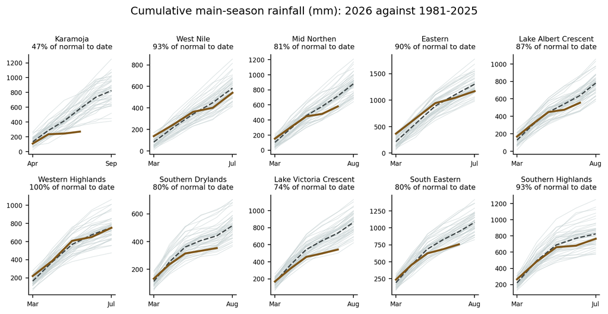

Cumulative rainfall over each zone’s main-season window, zone mean of district series. Gray: every year 1981-2025; dashed: the 1981-2025 mean; brown: 2026 through July (the ERA5 record’s edge). The percentage is 2026 season-to-date as a share of the normal (1981-2025 mean) season-to-date — the same basis as the district ranking below.

```python
cal = stratus.load_parquet_from_blob(f"{UGA_DIR}/asap_crop_calendar.parquet", stage="dev")
dz = stratus.load_parquet_from_blob(f"{UGA_DIR}/asap_district_zones.parquet", stage="dev")
zones = ["Karamoja", "West Nile", "Mid Northen", "Eastern", "Lake Albert Crescent",
         "Western Highlands", "Southern Drylands", "Lake Victoria Crescent",
         "South Eastern", "Southern Highlands"]
jiaf_pcodes = set(uct.load_jiaf_pin()["pcode"])

dk2mo = lambda d: int(np.ceil(d / 3))
main_cal = cal[cal["crop_name"].fillna("").str.contains("Maize")
               & ~cal["crop_name"].fillna("").str.contains("Second|North")]
season_win = {r["zone"]: (dk2mo(r["sos_s"]), dk2mo(r["eos_e"])) for _, r in main_cal.iterrows()}
season_win["Karamoja"] = (4, 9)   # wet season from ERA5 climatology; no ASAP calendar

e_all = era5_2.merge(dz[["pcode", "zone", "district"]], on="pcode")
e_all["yr"], e_all["mo"] = e_all["valid_date"].dt.year, e_all["valid_date"].dt.month
e_all["mm"] = e_all["mean"] * e_all["mo"].map(lambda m: calendar.monthrange(2025, m)[1])
LATEST_OBS = int(e_all.loc[e_all['yr'] == 2026, 'mo'].max())

fig, axes = plt.subplots(2, 5, figsize=(9.5, 4.8))
for ax, zone in zip(axes.flat, zones):
    m0, m1 = season_win[zone]
    mos = list(range(m0, m1 + 1))
    zm2 = (e_all[(e_all["zone"] == zone) & (e_all["mo"].isin(mos))]
           .groupby(["yr", "mo"])["mm"].mean().unstack().reindex(columns=mos))
    cum = zm2.cumsum(axis=1)
    hist = cum.loc[cum.index < 2026]
    for _, row in hist.iterrows():
        ax.plot(mos, row.values, color="#c4d0d1", lw=0.6, alpha=0.6)
    ax.plot(mos, hist.mean(), color="#3f4748", lw=1.4, ls="--")
    upto = [m for m in mos if m <= LATEST_OBS]
    if 2026 in cum.index and upto:
        ax.plot(upto, cum.loc[2026, upto], color="#7f5619", lw=2.2)
        # mean basis, matching the district ranking below (was median: the two
        # figures silently used different definitions of "normal")
        pct = 100 * cum.loc[2026, upto[-1]] / hist[upto[-1]].mean()
        ax.set_title(f"{zone}\n{pct:.0f}% of normal to date", fontsize=8)
    ax.set_xticks([mos[0], mos[-1]], [calendar.month_abbr[mos[0]], calendar.month_abbr[mos[-1]]], fontsize=7)
    ax.tick_params(axis='y', labelsize=7)
    ax.spines[["top", "right"]].set_visible(False)
fig.suptitle("Cumulative main-season rainfall (mm): 2026 against 1981-2025", y=1.0)
plt.tight_layout()
plt.show()
```

**JIAF districts: season-to-date ranking**

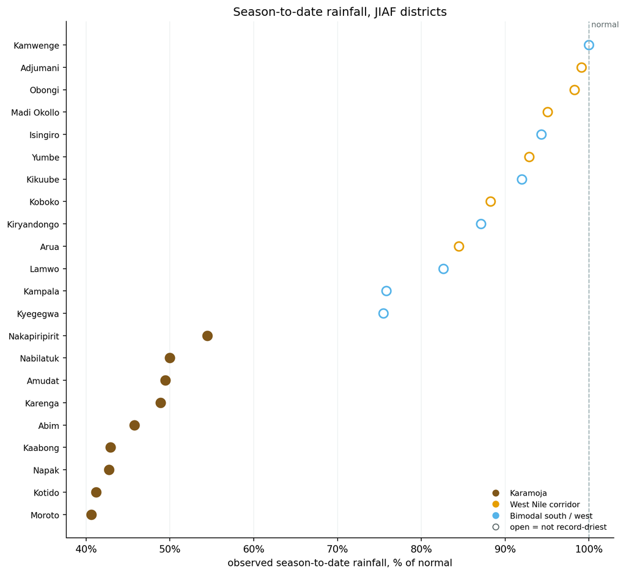

Observed season-to-date rainfall as % of the normal (1981-2025 mean) season-to-date, per JIAF district over its zone’s calendar window. Filled markers are districts having their driest season-to-date since 1981.

```python
std_rows = []
for (pc, dist, zone), gg in e_all[e_all["pcode"].isin(jiaf_pcodes)].groupby(["pcode", "district", "zone"]):
    m0, m1 = season_win[zone]
    mos = [m for m in range(m0, min(m1, LATEST_OBS) + 1)]
    std = gg[gg["mo"].isin(mos)].groupby("yr")["mm"].sum()
    hist = std[std.index < 2026]
    std_rows.append({"district": dist, "zone": zone, "pct": 100 * std[2026] / hist.mean(),
                     "driest": bool((hist < std[2026]).sum() == 0)})
sd = pd.DataFrame(std_rows)
sd["group"] = np.select([sd["zone"] == "Karamoja", sd["zone"] == "West Nile"],
                        ["Karamoja", "West Nile corridor"], "Bimodal south / west")
GC = {"Karamoja": "#7f5619", "West Nile corridor": "#e69f00", "Bimodal south / west": "#56b4e9"}
sd = sd.sort_values("pct").reset_index(drop=True)
fig, ax = plt.subplots(figsize=(9, 0.32 * len(sd) + 1.2))
for i, r in sd.iterrows():
    ax.plot(r["pct"], i, marker="o", ms=9, color=GC[r["group"]],
            markerfacecolor=GC[r["group"]] if r["driest"] else "white", markeredgewidth=1.6)
ax.set_yticks(range(len(sd)), sd["district"], fontsize=8.5)
ax.axvline(100, color="#9db1b3", lw=1, ls="--")
ax.text(100, len(sd) - 0.2, " normal", fontsize=8, color="#5e6a6b")
ax.set_xlabel("observed season-to-date rainfall, % of normal")
ax.xaxis.set_major_formatter(lambda v, _: f"{v:.0f}%")
ax.legend(handles=[plt.Line2D([], [], marker="o", ls="", color=c, label=g) for g, c in GC.items()]
                  + [plt.Line2D([], [], marker="o", ls="", color="#5e6a6b", markerfacecolor="white", label="open = not record-driest")],
          loc="lower right", frameon=False, fontsize=8)
ax.grid(axis="x", color="#eef1f1", zorder=0)
ax.spines[["top", "right"]].set_visible(False)
ax.set_title("Season-to-date rainfall, JIAF districts")
plt.tight_layout()
plt.show()
```

## Where it is heading: the forecast

The table and map below show, per unit, the worst qualifying drought slot at the latest SEAS5 issuance, using the app’s rule: valid trimesters (lead −2…4), rainy-season only, skill $r \ge 0.30$ (detrended), dry-side forecasts only (percentile < 50), severity = the drought return period. The RP says how *unusual* the forecast is, never how much water is missing, so each RP is paired with the forecast and climatological-normal seasonal totals (mm).

**region summary table**

```python
t = fc1.merge(cod1[["ADM1_PCODE", "ADM1_EN"]], left_on="pcode", right_on="ADM1_PCODE")
t = t[["ADM1_EN", "cat", "tri_label", "lead", "drought_rp", "pct", "r", "fc_mm", "nrm_mm"]]
t.columns = ["Region", "Category", "Trimester", "Lead", "Drought RP (yr)",
             "Percentile", "Skill r", "Forecast (mm)", "Normal (mm)"]
t.sort_values("Drought RP (yr)", ascending=False).style.hide(axis="index").format(
    {"Drought RP (yr)": "{:.1f}", "Percentile": "{:.1f}", "Skill r": "{:.2f}"}, na_rep="—")
```

| Region | Category | Trimester | Lead | Drought RP (yr) | Percentile | Skill r | Forecast (mm) | Normal (mm) |
| --- | --- | --- | --- | --- | --- | --- | --- | --- |
| Central | strongly below normal | Jul–Aug–Sep | -1 | 46.0 | 0.0 | 0.75 | 201 | 351 |
| Eastern | strongly below normal | Jun–Jul–Aug | -2 | 46.0 | 0.0 | 0.93 | 270 | 456 |
| Northern | strongly below normal | Jun–Jul–Aug | -2 | 46.0 | 0.0 | 0.95 | 192 | 422 |
| Western | strongly below normal | Jul–Aug–Sep | -1 | 46.0 | 0.0 | 0.74 | 200 | 351 |

**district drought map**

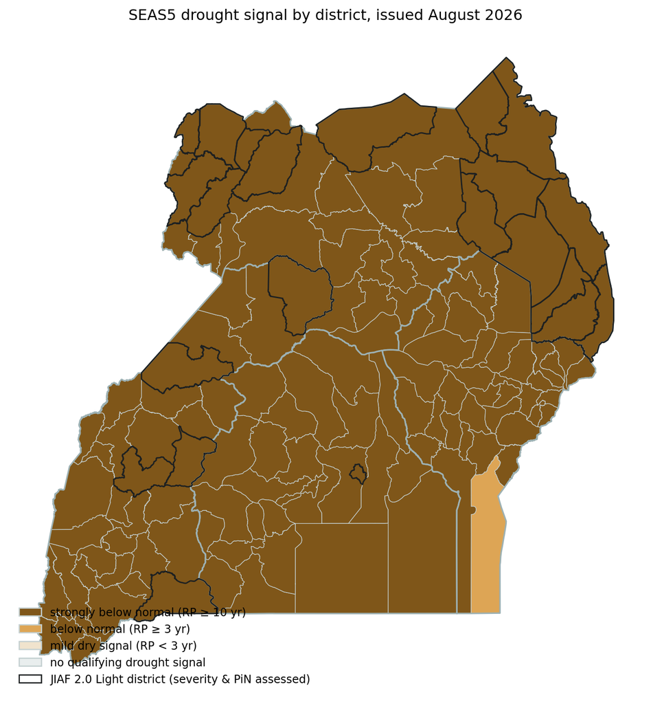

Worst qualifying drought slot per district, latest SEAS5 issuance, in the app’s category palette. The black outline marks the 22 districts assessed in the JIAF 2.0 Light exercise (severity and PiN); other districts are climate context only.

```python
g = cod2.merge(fc2, left_on="ADM2_PCODE", right_on="pcode", how="left")
jiaf_pcodes = set(uct.load_jiaf_pin()["pcode"])

def cat_color(row):
    if row["cat"] == "strongly below normal":
        return C_DROUGHT_VSEV
    if row["cat"] == "below normal":
        return C_DROUGHT_SEV
    if row["cat"] == "mild dry signal":
        return "#f0e3cd"
    return C_MUTED

fig, ax = plt.subplots(figsize=(9, 8))
g["color"] = g.apply(cat_color, axis=1)
g.plot(ax=ax, color=g["color"], edgecolor=C_EDGE, linewidth=0.5)
cod1.boundary.plot(ax=ax, color="#9db1b3", linewidth=1.2)
g[g["ADM2_PCODE"].isin(jiaf_pcodes)].boundary.plot(ax=ax, color="#1d2021", linewidth=1.1)
ax.set_axis_off()
ax.set_title(f"SEAS5 drought signal by district, issued {calendar.month_name[issued]} {issued_yr}")
ax.legend(handles=[
    Patch(facecolor=C_DROUGHT_VSEV, edgecolor=C_EDGE, label=f"strongly below normal (RP ≥ {THRESHOLDS['vsev_rp']} yr)"),
    Patch(facecolor=C_DROUGHT_SEV, edgecolor=C_EDGE, label=f"below normal (RP ≥ {THRESHOLDS['sev_rp']} yr)"),
    Patch(facecolor="#f0e3cd", edgecolor=C_EDGE, label="mild dry signal (RP < 3 yr)"),
    Patch(facecolor=C_MUTED, edgecolor=C_EDGE, label="no qualifying drought signal"),
    Patch(facecolor="none", edgecolor="#1d2021", label="JIAF 2.0 Light district (severity & PiN assessed)"),
], loc="lower left", frameon=False, fontsize=9)
plt.tight_layout()
plt.show()
```

**ImportantDry now, wet later**

The drought signal is concentrated in June to September 2026. Monthly percentiles below are vs 1981-2025, computed as the mean of the district series (`seas5_adm2` / `era5_adm2`) over the named unit. June was the driest June in the 45-year record at national, Northern-region, and Karamoja aggregation alike (observed); July sat at the 13th percentile nationally (Karamoja: the 0th). The August-issued forecast puts August at the 0th percentile on all three aggregations, and September at the 0th nationally and over Karamoja (Northern region: the 2nd). From October onward the same issuance forecasts wetter than normal (Northern region: Oct 93rd / Nov 96th / Dec 98th percentile), so a “wetter than normal OND” reading elsewhere in the app is correct and does not contradict this document. The Forecast × HNRP methodology is drought-side only and reports each unit’s *worst* qualifying slot, which lands on the Jun-Sep window. The table below gives every valid trimester so both sides are visible.

**Skill:** every reported slot passed the detrended $r \ge 0.30$ gate. The Jun-Jul-Aug slots show $r$ of 0.92 to 0.96 because they are in-season at an August issuance: June and July are already *observed*, so two-thirds of that signal is monitoring, not forecast. The fully-forecast Aug-Sep-Oct slots carry genuine forecast skill ($r$ 0.34 to 0.62, median 0.57), and each table row reports its own $r$.

**Crop relevance:** the Jun-Aug window carries 38-44% of total annual rainfall in every Karamoja district (ERA5 climatology, this analysis). What that means for production differs by agro-ecological zone; see Seasonal relevance below, built from the JRC ASAP crop calendars.

**full seasonal picture: forecast percentile by region × trimester**

```python
# Same vintage guard as worst_drought_slot: month-only selection would render
# last year's in-season rows whenever the adm1 pipeline ran before the current
# ERA5 month landed (this table once showed Aug 2025's JJA/JAS as "issued 2026").
iy1 = skill1[skill1["current_forecast_year"].notna()].copy()
iy1["_iy"] = iy1.apply(_actual_issued_year, axis=1)
iy1 = iy1[(iy1["issued_month"] == issued) & (iy1["_iy"] == issued_yr)]
iy1 = iy1[iy1.apply(lambda r: _tri_valid(TRIMESTERS[r["trimester"]], issued), axis=1)]
iy1["region"] = iy1["pcode"].map(dict(zip(cod1["ADM1_PCODE"], cod1["ADM1_EN"])))
iy1["lead"] = iy1["trimester"].map(lambda t: trimester_lead(issued, TRIMESTERS[t]))
order = iy1.drop_duplicates("trimester").sort_values("lead")
piv = iy1.pivot_table(index="region", columns="trimester", values="forecast_percentile")
piv = piv[order["trimester"]]
piv.columns = [f"{_tri_label(TRIMESTERS[t])} (lead {l})" for t, l in zip(order["trimester"], order["lead"])]
(piv.style.format("{:.0f}")
    .background_gradient(cmap="BrBG", vmin=0, vmax=100, axis=None)
    .set_caption("Forecast percentile vs 1981-2025 for each valid trimester, "
                 f"issued {calendar.month_name[issued]} {issued_yr} (brown = dry, green = wet). "
                 "In-season trimesters (negative leads) mix observed months with the forecast."))
```

Table 1: Forecast percentile vs 1981-2025 for each valid trimester, issued August 2026 (brown = dry, green = wet). In-season trimesters (negative leads) mix observed months with the forecast.

| region | Jun–Jul–Aug (lead -2) | Jul–Aug–Sep (lead -1) | Aug–Sep–Oct (lead 0) | Sep–Oct–Nov (lead 1) | Oct–Nov–Dec (lead 2) | Nov–Dec–Jan (lead 3) | Dec–Jan–Feb (lead 4) |
| --- | --- | --- | --- | --- | --- | --- | --- |
| Central | 2 | 0 | 9 | 71 | 96 | 89 | 96 |
| Eastern | 0 | 0 | 7 | 60 | 93 | 89 | 96 |
| Northern | 0 | 0 | 0 | 24 | 89 | 93 | 96 |
| Western | 4 | 0 | 0 | 13 | 89 | 89 | 96 |

**WarningNearly every district is at the maximum return period**

The empirical RP is capped at 46 years (the 45-year record + 1), and at this issuance almost all districts hit that cap: the forecast is drier than anything in the historical record across nearly the whole country, so the RP map cannot differentiate *within* Uganda. The RP says how unusual the season is. The map below shows how deep the deficit is (the forecast seasonal total as a share of the climatological normal), which is where districts differ.

**forecast deficit map**

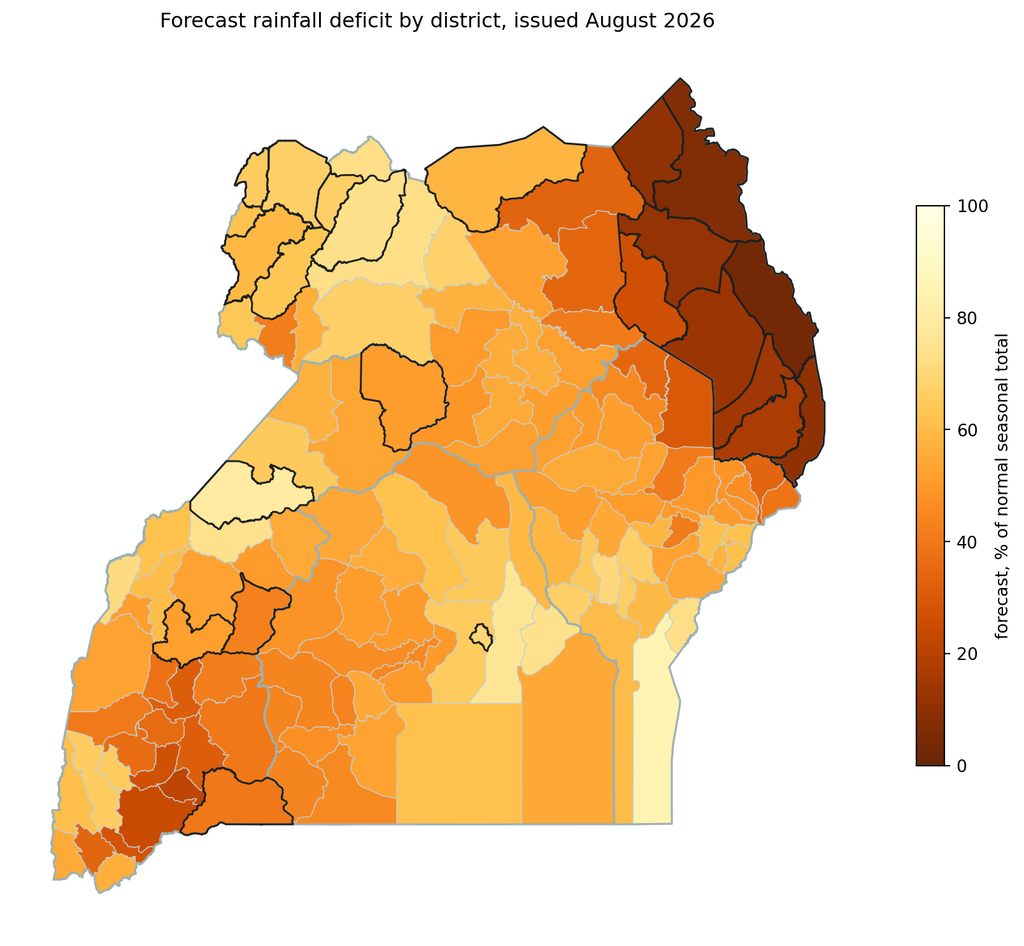

Forecast seasonal total as % of the climatological normal, for each district’s worst qualifying slot. Darker = deeper deficit.

```python
gd = g[g["fc_mm"].notna() & g["nrm_mm"].notna()].copy()
gd["pct_normal"] = 100 * gd["fc_mm"] / gd["nrm_mm"]

fig, ax = plt.subplots(figsize=(9, 8))
g.plot(ax=ax, color=C_MUTED, edgecolor=C_EDGE, linewidth=0.5)
gd.plot(ax=ax, column="pct_normal", cmap="YlOrBr_r", vmin=0, vmax=100,
        edgecolor=C_EDGE, linewidth=0.5,
        legend=True, legend_kwds={"label": "forecast, % of normal seasonal total",
                                  "shrink": 0.6})
cod1.boundary.plot(ax=ax, color="#9db1b3", linewidth=1.2)
g[g["ADM2_PCODE"].isin(jiaf_pcodes)].boundary.plot(ax=ax, color="#1d2021", linewidth=1.1)
ax.set_axis_off()
ax.set_title(f"Forecast rainfall deficit by district, issued {calendar.month_name[issued]} 2026")
plt.tight_layout()
plt.show()
```

The same issuance also forecasts a strongly wet Oct-Dec; the flood side of that story has its own section at the end of this document, so the drought reading here stays in one piece.

## Seasonal relevance: crops, pasture, and timing

Cropping seasons come from the JRC ASAP sub-national crop calendars (planting, growth and harvest windows per agro-ecological zone, in 10-day dekads), with each CODAB district assigned to its zone (`pipeline/build_uga_crop_calendar.py`). ASAP calendars only maize, beans and millet: Uganda’s root and perennial crops (cassava, banana) and Karamoja’s sorghum are not calendared, and perennials buffer a rainfall shock differently from cereals. The zones fall into three different situations:

- **Karamoja is pastoral, not a cropping zone.** ASAP publishes no crop calendar for it: 91% of the zone is rangeland and only 4% cropland. The record-dry Jun-Aug, its rainfall peak, is first a pasture, water and livestock crisis, hitting the sparse sorghum patches on top. An unusually wet Oct-Dec can recharge water points and regrow pasture for herds; for the cropped patches it comes after the zone’s single season has already failed, and nothing replanted grows before the next rains around April.
- **West Nile is unimodal in ASAP** (no second-season crops): planting March to April, harvest June to July. Stage timing matters here: planting rains were wet (March at the 91st percentile) and growth was mixed (April 22nd, May 47th), so the record-dry June hit *maturation and harvest* rather than grain-fill, and the season-to-date accumulation is 84-99% of normal (see “Where the season stands” above). That points to a season close to normal in water terms, with the risk concentrated in harvest conditions and late-planted fields. What makes it a priority anyway is what comes after: there is no second planting until March 2027, so whatever the season yielded has to carry the refugee-hosting districts (Yumbe, Adjumani, Madi-Okollo & Terego, Obongi, Koboko, Arua/Terego, Moyo) through the whole dry stretch, and the wet OND forecast offers no cropping recovery there.
- **The bimodal zones** (Mid Northern incl. Lamwo; Lake Albert Crescent incl. Kiryandongo/Kikuube; Western Highlands incl. Kamwenge/Kyegegwa; Southern Drylands incl. Isingiro; Lake Victoria Crescent incl. Kampala): the dry window hits main-season harvest (Jun-Aug), and second-season planting (Aug-Oct) risks poor establishment in the record-dry Aug-Sep, but the strongly wet Oct-Dec then favors whatever gets established. A delayed second-season start with good follow-on rains is the base case there.

**seasonal calendar figure**

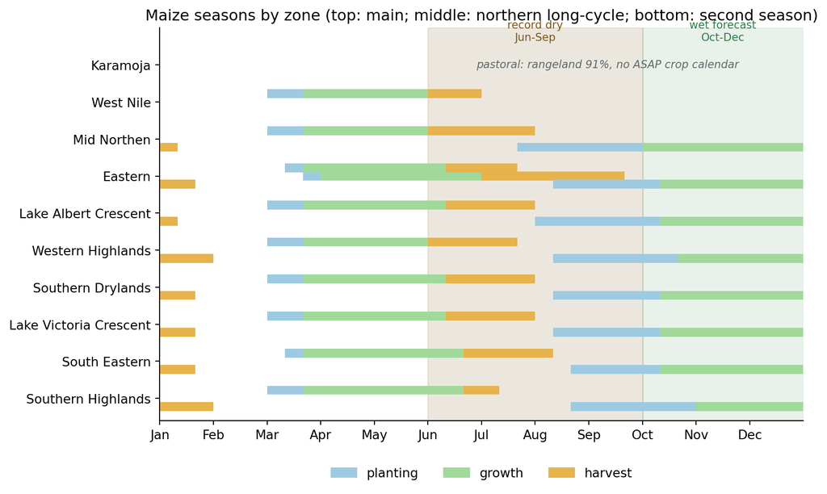

Maize seasons per ASAP agro-ecological zone. ASAP calendars Uganda for maize, beans and millet; beans and millet share maize’s windows everywhere except Eastern, where millet’s harvest runs about a month longer. Eastern’s long-cycle northern maize is the middle bar. Brown band: the record-dry Jun-Sep window; green band: the wetter-than-normal Oct-Dec forecast. Karamoja has no ASAP crop calendar; it is 91% rangeland.

```python
def dk(d):  # dekad (1-36) -> month-axis position (1.0 = Jan 1, 13.0 = Dec 31)
    return 1 + (d - 1) / 3

maize = cal[cal["crop_name"].str.contains("Maize", na=False)].copy()
maize["season"] = np.select(
    [maize["crop_name"].str.contains("Second"), maize["crop_name"].str.contains("North")],
    ["second", "north"], "main")

C_PLANT, C_GROW, C_HARV = "#9ecae1", "#a1d99b", "#e6b34c"
fig, ax = plt.subplots(figsize=(9, 5.5))
for i, z in enumerate(zones):
    y = len(zones) - 1 - i
    rows = maize[maize["zone"] == z]
    if rows.empty:
        ax.text(6.9, y, "pastoral: rangeland 91%, no ASAP crop calendar",
                va="center", fontsize=8.5, color="#5b6b6d", style="italic")
        continue
    for _, r in rows.iterrows():
        off = {"main": 0.22, "north": 0.0, "second": -0.22}[r["season"]]
        segs = [(dk(r["sos_s"]), dk(r["sos_e"]), C_PLANT),
                (dk(r["sos_e"]), dk(r["eos_s"]) if r["eos_s"] > r["sos_e"] else 13, C_GROW)]
        if r["eos_s"] > r["sos_e"]:                     # same calendar year
            segs.append((dk(r["eos_s"]), dk(r["eos_e"]), C_HARV))
        else:                                           # wraps into January
            segs += [(1, dk(r["eos_s"]), C_GROW), (dk(r["eos_s"]), dk(r["eos_e"]), C_HARV)]
        for x0, x1, c in segs:
            ax.barh(y + off, x1 - x0, left=x0, height=0.24, color=c, edgecolor="none")
ax.axvspan(6, 10, color="#7f5619", alpha=0.14, zorder=0)
ax.axvspan(10, 13, color="#2a7e43", alpha=0.10, zorder=0)
ax.text(8.0, len(zones) - 0.35, "record dry\nJun-Sep", ha="center", fontsize=8.5, color="#7f5619")
ax.text(11.5, len(zones) - 0.35, "wet forecast\nOct-Dec", ha="center", fontsize=8.5, color="#2a7e43")
ax.set_yticks(range(len(zones)), zones[::-1])
ax.set_xticks(np.arange(1, 13), [calendar.month_abbr[m] for m in range(1, 13)])
ax.set_xlim(1, 13); ax.set_ylim(-0.6, len(zones))
ax.legend(handles=[Patch(color=C_PLANT, label="planting"), Patch(color=C_GROW, label="growth"),
                   Patch(color=C_HARV, label="harvest")],
          loc="upper center", bbox_to_anchor=(0.5, -0.09), ncol=3, frameon=False)
ax.spines[["top", "right"]].set_visible(False)
ax.set_title("Maize seasons by zone (top: main; middle: northern long-cycle; bottom: second season)")
plt.tight_layout()
plt.show()
```

### Did the drought hit when it matters for crops?

**observed 2026 monthly percentile by zone**

```python
e2z = era5_2.merge(dz[["pcode", "zone"]], on="pcode")
zm = (e2z.groupby(["zone", e2z["valid_date"].dt.year.rename("yr"),
                   e2z["valid_date"].dt.month.rename("mo")])["mean"]
          .mean().reset_index())
obs_rows = []
for zone, gg in zm.groupby("zone"):
    row = {"zone": zone}
    for mo in range(1, 8):
        cur = gg[(gg["yr"] == 2026) & (gg["mo"] == mo)]["mean"]
        hist = gg[(gg["yr"] < 2026) & (gg["mo"] == mo)]["mean"]
        row[calendar.month_abbr[mo]] = 100 * (hist < cur.iloc[0]).mean()
    obs_rows.append(row)
obs = pd.DataFrame(obs_rows).set_index("zone").sort_index()
(obs.style.format("{:.0f}")
    .background_gradient(cmap="BrBG", vmin=0, vmax=100, axis=None)
    .set_caption("Observed 2026 monthly rainfall percentile vs 1981-2025 "
                 "(ERA5, zone mean of district series; brown = dry, green = wet)"))
```

Table 2: Observed 2026 monthly rainfall percentile vs 1981-2025 (ERA5, zone mean of district series; brown = dry, green = wet)

| zone | Jan | Feb | Mar | Apr | May | Jun | Jul |
| --- | --- | --- | --- | --- | --- | --- | --- |
| Eastern | 4 | 96 | 98 | 22 | 36 | 0 | 4 |
| Karamoja | 9 | 89 | 98 | 38 | 24 | 0 | 0 |
| Lake Albert Crescent | 7 | 93 | 76 | 20 | 47 | 0 | 36 |
| Lake Victoria Crescent | 7 | 96 | 60 | 4 | 9 | 0 | 7 |
| Mid Northen | 11 | 91 | 80 | 24 | 29 | 0 | 20 |
| South Eastern | 7 | 96 | 69 | 18 | 9 | 0 | 9 |
| Southern Drylands | 4 | 91 | 71 | 13 | 20 | 9 | 31 |
| Southern Highlands | 13 | 87 | 78 | 18 | 33 | 9 | 78 |
| West Nile | 9 | 91 | 91 | 22 | 47 | 0 | 49 |
| Western Highlands | 24 | 96 | 87 | 9 | 67 | 4 | 73 |

**JIAF districts by agro-ecological zone**

```python
jiaf_pin = uct.load_jiaf_pin()
zj = (dz[dz["pcode"].isin(set(jiaf_pin["pcode"]))]
      .merge(jiaf_pin.groupby("pcode", as_index=False)["joint_pin"].sum(), on="pcode", how="left"))
ztbl = (zj.groupby("zone")
          .agg(districts=("district", lambda s: ", ".join(sorted(s))),
               joint_pin=("joint_pin", "sum"))
          .sort_values("joint_pin", ascending=False).reset_index())
ztbl.columns = ["ASAP zone", "JIAF districts", "Joint PiN"]
ztbl.style.hide(axis="index").format({"Joint PiN": "{:,.0f}"})
```

| ASAP zone | JIAF districts | Joint PiN |
| --- | --- | --- |
| West Nile | Adjumani, Arua, Koboko, Madi Okollo, Obongi, Yumbe | 1,049,455 |
| Karamoja | Abim, Amudat, Kaabong, Karenga, Kotido, Moroto, Nabilatuk, Nakapiripirit, Napak | 847,143 |
| Lake Albert Crescent | Kikuube, Kiryandongo | 206,087 |
| Western Highlands | Kamwenge, Kyegegwa | 203,079 |
| Mid Northen | Lamwo | 195,234 |
| Southern Drylands | Isingiro | 194,028 |
| Lake Victoria Crescent | Kampala | 0 |

## Why it matters: people already in need

JIAF classifies **areas**; PiN counts **people**. The joint PiN per district × population group is the highest sectoral PiN (JIAF 2.0 mosaic rule); the intersectoral severity is the area’s class.

Two honesty notes on reading the table. The intersectoral severity scale is **saturated** in this dataset: every district × group is class 2 or 3, 21 of the 22 districts include a class-3 area (Kampala is the exception), and 100% of the joint PiN sits in severity-3 areas — so the color-graded Severity column separates almost nothing *within* the assessed set. Where the data do differentiate is the sectoral classes (Nutrition reaches 4 in Kaabong, Karenga, Kotido and Moroto — exactly the Karamoja core). And the PiN is a **pre-shock baseline** from the 2026 planning cycle: it cannot respond to the forecast shock this document is about, only be read alongside it.

**JIAF severity + PiN table**

```python
pin = uct.load_jiaf_pin()
sev = uct.load_jiaf_severity()
j = pin.merge(sev[["district", "pop_group", "intersectoral_severity"]],
              on=["district", "pop_group"], how="left")
tbl = j[["sub_region", "district", "pop_group", "population",
         "intersectoral_severity", "joint_pin", "pct_population"]].copy()
tbl["pct_population"] = 100 * tbl["pct_population"]
tbl.columns = ["Sub-region", "District", "Group", "Population",
               "Severity", "Joint PiN", "PiN % of pop."]
(tbl.sort_values(["Sub-region", "District", "Group"])
    .style.hide(axis="index")
    .format({"Population": "{:,.0f}", "Joint PiN": "{:,.0f}", "PiN % of pop.": "{:.0f}%"}, na_rep="—")
    .background_gradient(subset=["Severity"], cmap=ListedColormap(JIAF_COLORS), vmin=1, vmax=5))
```

| Sub-region | District | Group | Population | Severity | Joint PiN | PiN % of pop. |
| --- | --- | --- | --- | --- | --- | --- |
| Acholi | Lamwo | Host community | 213,156 | 3.000000 | 114,912 | 54% |
| Acholi | Lamwo | Refugees | 98,882 | 3.000000 | 80,322 | 81% |
| Kampala (urban) | Kampala | Refugees | 170,474 | 2.000000 | — | — |
| Karamoja | Abim | Host community | 144,084 | 3.000000 | 74,261 | 52% |
| Karamoja | Amudat | Host community | 203,358 | 3.000000 | 132,183 | 65% |
| Karamoja | Kaabong | Host community | 264,631 | 3.000000 | 142,009 | 54% |
| Karamoja | Karenga | Host community | 100,375 | 3.000000 | 56,210 | 56% |
| Karamoja | Kotido | Host community | 219,734 | 3.000000 | 142,828 | 65% |
| Karamoja | Moroto | Host community | 103,639 | 3.000000 | 53,995 | 52% |
| Karamoja | Nabilatuk | Host community | 136,785 | 3.000000 | 72,814 | 53% |
| Karamoja | Nakapiripirit | Host community | 111,681 | 3.000000 | 58,132 | 52% |
| Karamoja | Napak | Host community | 211,830 | 3.000000 | 114,711 | 54% |
| Mid-West | Kikuube | Host community | 379,547 | 2.000000 | — | — |
| Mid-West | Kikuube | Refugees | 157,991 | 3.000000 | 104,274 | 66% |
| Mid-West | Kiryandongo | Host community | 364,872 | 2.000000 | — | — |
| Mid-West | Kiryandongo | Refugees | 166,907 | 3.000000 | 101,813 | 61% |
| South West | Isingiro | Host community | 635,077 | 2.000000 | — | — |
| South West | Isingiro | Refugees | 281,357 | 3.000000 | 188,509 | 67% |
| South West | Isingiro | Refugees | 281,357 | 3.000000 | 188,509 | 67% |
| South West | Isingiro | Refugees | 8,238 | 3.000000 | 5,519 | 67% |
| South West | Isingiro | Refugees | 8,238 | 3.000000 | 5,519 | 67% |
| South West | Kamwenge | Host community | 337,167 | 2.000000 | — | — |
| South West | Kamwenge | Refugees | 108,799 | 3.000000 | 93,567 | 86% |
| South West | Kyegegwa | Host community | 501,120 | 2.000000 | — | — |
| South West | Kyegegwa | Refugees | 138,623 | 3.000000 | 109,512 | 79% |
| West Nile | Adjumani | Host community | 300,590 | 3.000000 | 72,120 | 24% |
| West Nile | Adjumani | Refugees | 235,088 | 3.000000 | 157,509 | 67% |
| West Nile | Koboko | Host community | 271,781 | 2.000000 | — | — |
| West Nile | Koboko | Refugees | 6,528 | 3.000000 | 2,350 | 36% |
| West Nile | Madi-Okollo & Terego | Host community | 501,304 | 3.000000 | 107,067 | 21% |
| West Nile | Madi-Okollo & Terego | Refugees | 204,257 | 3.000000 | 120,512 | 59% |
| West Nile | Obongi | Host community | 142,983 | 3.000000 | 41,265 | 29% |
| West Nile | Obongi | Refugees | 144,330 | 3.000000 | 83,423 | 58% |
| West Nile | Terego | Refugees | 79,832 | 3.000000 | 48,777 | 61% |
| West Nile | Yumbe | Host community | 945,100 | 3.000000 | 275,780 | 29% |
| West Nile | Yumbe | Refugees | 209,928 | 3.000000 | 140,652 | 67% |

**national totals**

```python
tot = j.groupby("pop_group")[["population", "joint_pin"]].sum()
tot.loc["TOTAL"] = tot.sum()
tot.columns = ["Population baseline", "Joint PiN"]
tot.style.format("{:,.0f}")
```

| pop_group | Population baseline | Joint PiN |
| --- | --- | --- |
| Host community | 6,088,814 | 1,458,287 |
| Refugees | 2,300,829 | 1,430,767 |
| TOTAL | 8,389,643 | 2,889,054 |

## Response: PiN → targeted → reached

Max targeted / achieved people from the response-monitoring workbooks (2026-08-19). Each admin level in the source is an independent rollup, not a sum of the finer level: district figures here are the district-level series, and levels must never be added together.

One join caveat, resolved conservatively: the workbooks use post-split districts and have an “Arua” row but no “Terego” row, while JIAF assesses Terego and not Arua - and the two share a CODAB pcode (Terego split from Arua in 2020) without being the same territory. Response figures therefore attach to JIAF rows by district *name*: **Terego shows “none reported” rather than inheriting Arua’s figures**, and whether Arua’s reporting actually covers Terego is a question to put to the country team. The combined JIAF unit “Madi-Okollo & Terego” takes the workbook’s “Madi Okollo” row, its dominant part.

**district funnel chart**

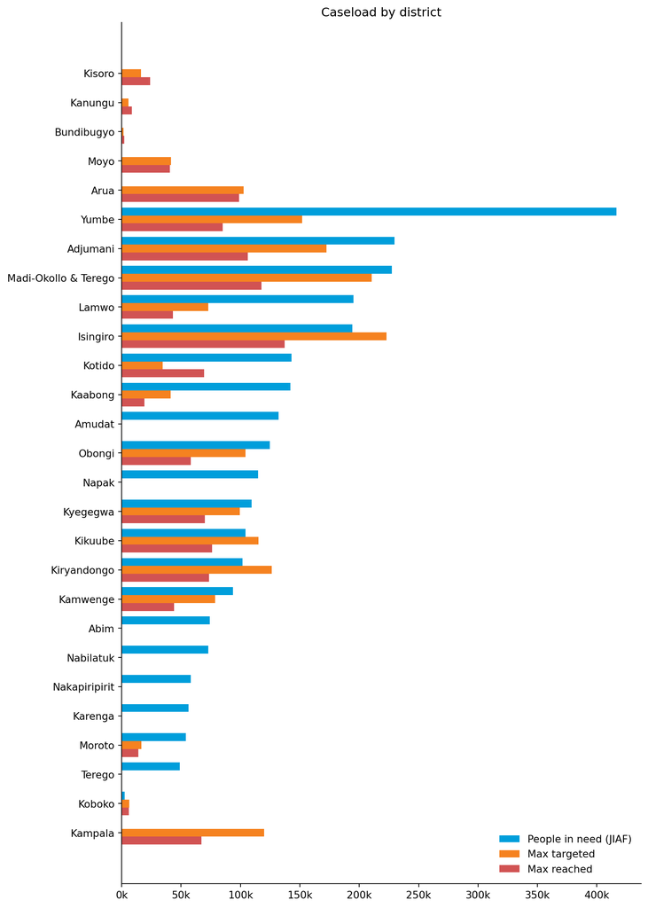

```python
tgt = uct.load_reach("targeted", level=2)[["pcode", "adm2_name", "total"]].rename(columns={"total": "targeted"})
rea = uct.load_reach("achieved", level=2)[["pcode", "adm2_name", "total"]].rename(columns={"total": "reached"})
reach = tgt.merge(rea, on=["pcode", "adm2_name"], how="outer")
reach["_k"] = reach["adm2_name"].str.strip().str.lower()

# The workbooks use post-split districts, JIAF uses operational units, and a
# pcode is not an identity: workbook "Arua" and JIAF "Terego" both map to
# UG3072 (Terego split from Arua in 2020) while being disjoint territories, so
# a pcode join would credit Arua's response to Terego's row. Reach therefore
# attaches by NAME, with one documented exception: the combined JIAF unit
# "Madi-Okollo & Terego" takes workbook "Madi Okollo" (its dominant part).
REACH_NAME_FOR_JIAF = {"madi-okollo & terego": "madi okollo"}

def attach_reach(df, name_col="district"):
    k = df[name_col].str.strip().str.lower().map(lambda s: REACH_NAME_FOR_JIAF.get(s, s))
    return (df.assign(_k=k)
              .merge(reach[["_k", "targeted", "reached"]], on="_k", how="left")
              .drop(columns="_k"))

dpin = pin.groupby(["pcode"], as_index=False).agg(district=("district", "first"),
                                                  pin=("joint_pin", "sum"))
jf = attach_reach(dpin)
matched = set(jf["district"].str.strip().str.lower().map(lambda s: REACH_NAME_FOR_JIAF.get(s, s)))
extra = reach[~reach["_k"].isin(matched)].rename(columns={"adm2_name": "district"})
fun = pd.concat([jf, extra[["pcode", "district", "targeted", "reached"]]], ignore_index=True)
fun = fun[fun[["targeted", "reached"]].notna().any(axis=1) | fun["pin"].notna()]
fun = fun.sort_values("pin", ascending=True).fillna(0)

fig, ax = plt.subplots(figsize=(9, 0.42 * len(fun) + 1.2))
y = np.arange(len(fun))
h = 0.27
ax.barh(y + h, fun["pin"], height=h, color=C_PIN, label="People in need (JIAF)")
ax.barh(y, fun["targeted"], height=h, color=C_TGT, label="Max targeted")
ax.barh(y - h, fun["reached"], height=h, color=C_REA, label="Max reached")
ax.set_yticks(y, fun["district"])
ax.xaxis.set_major_formatter(lambda v, _: f"{v/1e3:,.0f}k")
ax.legend(frameon=False, loc="lower right")
ax.spines[["top", "right"]].set_visible(False)
ax.set_title("Caseload by district")
plt.tight_layout()
plt.show()
```

## Forecast × caseload

The readout the app’s tab exists for: where a bad drought forecast meets a large caseload. Districts below are the JIAF 2.0 Light districts joined to their forecast slot; the two operational units that share a CODAB polygon (Terego sits inside CODAB’s Arua; “Madi-Okollo & Terego” maps to Madi Okollo) inherit that polygon’s forecast. The last column adds OND flood-extent context: pixel-mean flood recurrence is low across the whole assessed set (0-6%, highest on the Albert Nile at Obongi) - the flood-extent hotspots lie outside the JIAF footprint, in the Teso wetlands (see the flood section).

**combined district table**

```python
comb = (j.groupby(["pcode", "sub_region", "district"], as_index=False)
          .agg(population=("population", "sum"), joint_pin=("joint_pin", "sum"),
               worst_sev=("intersectoral_severity", "max"))
          .merge(fc2, on="pcode", how="left"))
comb = attach_reach(comb)   # by name, not pcode — see the response section
comb["pct_normal"] = 100 * comb["fc_mm"] / comb["nrm_mm"]

# OND flood-extent context for the assessed districts (pixel-mean recurrence;
# low everywhere in the JIAF set - the extent hotspots lie outside it).
flrec = stratus.load_parquet_from_blob(f"{UGA_DIR}/flood_ond_adm2.parquet", stage="dev")
comb = comb.merge(flrec[["pcode", "recurrence_any"]], on="pcode", how="left")

# How much of a normal year's rain falls in this trimester (days-weighted ERA5
# climatology): the deficit matters more where the season carries the year.
mc2 = (era5_2.assign(month=era5_2["valid_date"].dt.month)
             .groupby(["pcode", "month"])["mean"].mean().reset_index())
mc2["mm"] = mc2["mean"] * mc2["month"].map(lambda m: calendar.monthrange(2025, m)[1])
annual_mm = mc2.groupby("pcode")["mm"].sum()

def tri_share(pcode, tri):
    if pd.isna(tri):
        return None
    mm = mc2[(mc2["pcode"] == pcode) & (mc2["month"].isin(TRIMESTERS[tri]))]["mm"].sum()
    return 100 * mm / annual_mm[pcode]

comb["tri_share"] = [tri_share(p, t) for p, t in zip(comb["pcode"], comb["trimester"])]
out = comb[["sub_region", "district", "worst_sev", "joint_pin", "targeted", "reached",
            "cat", "tri_label", "drought_rp", "pct_normal", "tri_share", "r",
            "fc_mm", "nrm_mm", "recurrence_any"]].copy()
out.columns = ["Sub-region", "District", "Severity", "Joint PiN", "Targeted", "Reached",
               "Forecast category", "Trimester", "Drought RP (yr)", "% of normal",
               "Season share of annual rain", "Skill r", "Forecast (mm)", "Normal (mm)",
               "OND flood recurrence"]
(out.sort_values(["% of normal", "Joint PiN"], ascending=[True, False])
    .style.hide(axis="index")
    .format({"Joint PiN": "{:,.0f}", "Targeted": "{:,.0f}", "Reached": "{:,.0f}",
             "Drought RP (yr)": "{:.1f}", "% of normal": "{:.0f}%",
             "Season share of annual rain": "{:.0f}%", "Skill r": "{:.2f}",
             "OND flood recurrence": "{:.0%}"}, na_rep="—")
    .background_gradient(subset=["Severity"], cmap=ListedColormap(JIAF_COLORS), vmin=1, vmax=5))
```

| Sub-region | District | Severity | Joint PiN | Targeted | Reached | Forecast category | Trimester | Drought RP (yr) | % of normal | Season share of annual rain | Skill r | Forecast (mm) | Normal (mm) | OND flood recurrence |
| --- | --- | --- | --- | --- | --- | --- | --- | --- | --- | --- | --- | --- | --- | --- |
| Karamoja | Moroto | 3.000000 | 53,995 | 16,463 | 13,844 | strongly below normal | Jun–Jul–Aug | 46.0 | 3% | 43% | 0.96 | 11 | 319 | 3% |
| Karamoja | Kaabong | 3.000000 | 142,009 | 41,345 | 19,047 | strongly below normal | Jun–Jul–Aug | 46.0 | 7% | 44% | 0.95 | 31 | 443 | 1% |
| Karamoja | Amudat | 3.000000 | 132,183 | — | — | strongly below normal | Jun–Jul–Aug | 46.0 | 10% | 43% | 0.94 | 61 | 582 | 3% |
| Karamoja | Karenga | 3.000000 | 56,210 | — | — | strongly below normal | Jun–Jul–Aug | 46.0 | 11% | 41% | 0.94 | 42 | 395 | 4% |
| Karamoja | Kotido | 3.000000 | 142,828 | 34,591 | 69,284 | strongly below normal | Jun–Jul–Aug | 46.0 | 12% | 44% | 0.94 | 43 | 373 | 6% |
| Karamoja | Napak | 3.000000 | 114,711 | — | — | strongly below normal | Jun–Jul–Aug | 46.0 | 13% | 39% | 0.95 | 49 | 373 | 6% |
| Karamoja | Nabilatuk | 3.000000 | 72,814 | — | — | strongly below normal | Jun–Jul–Aug | 46.0 | 14% | 38% | 0.93 | 57 | 400 | 5% |
| Karamoja | Nakapiripirit | 3.000000 | 58,132 | — | — | strongly below normal | Jun–Jul–Aug | 46.0 | 17% | 38% | 0.92 | 92 | 537 | 4% |
| Karamoja | Abim | 3.000000 | 74,261 | — | — | strongly below normal | Jun–Jul–Aug | 46.0 | 26% | 40% | 0.95 | 115 | 436 | 5% |
| South West | Isingiro | 3.000000 | 388,056 | 223,051 | 137,112 | strongly below normal | Jul–Aug–Sep | 46.0 | 40% | 17% | 0.59 | 59 | 148 | 3% |
| South West | Kyegegwa | 3.000000 | 109,512 | 99,300 | 70,046 | strongly below normal | Jul–Aug–Sep | 46.0 | 43% | 23% | 0.67 | 99 | 231 | 1% |
| Mid-West | Kiryandongo | 3.000000 | 101,813 | 126,451 | 73,627 | strongly below normal | Jul–Aug–Sep | 46.0 | 51% | 30% | 0.79 | 220 | 430 | 3% |
| South West | Kamwenge | 3.000000 | 93,567 | 78,600 | 44,004 | strongly below normal | Jul–Aug–Sep | 46.0 | 52% | 20% | 0.64 | 121 | 233 | 1% |
| Acholi | Lamwo | 3.000000 | 195,234 | 72,749 | 43,061 | strongly below normal | Jun–Jul–Aug | 46.0 | 58% | 35% | 0.94 | 305 | 525 | 2% |
| West Nile | Terego | 3.000000 | 48,777 | — | — | strongly below normal | Aug–Sep–Oct | 46.0 | 59% | 40% | 0.58 | 223 | 376 | 0% |
| West Nile | Madi-Okollo & Terego | 3.000000 | 227,579 | 210,446 | 117,815 | strongly below normal | Aug–Sep–Oct | 46.0 | 64% | 38% | 0.58 | 230 | 362 | 4% |
| West Nile | Koboko | 3.000000 | 2,350 | 6,314 | 5,998 | strongly below normal | Aug–Sep–Oct | 46.0 | 65% | 42% | 0.59 | 385 | 588 | 0% |
| West Nile | Obongi | 3.000000 | 124,688 | 104,100 | 58,279 | strongly below normal | Jul–Aug–Sep | 23.0 | 67% | 33% | 0.79 | 269 | 402 | 6% |
| West Nile | Yumbe | 3.000000 | 416,432 | 151,800 | 84,983 | strongly below normal | Jun–Jul–Aug | 46.0 | 67% | 33% | 0.93 | 247 | 368 | 1% |
| Kampala (urban) | Kampala | 2.000000 | 0 | 120,000 | 67,180 | strongly below normal | Jul–Aug–Sep | 46.0 | 70% | 20% | 0.63 | 255 | 365 | 4% |
| West Nile | Adjumani | 3.000000 | 229,629 | 172,351 | 106,177 | strongly below normal | Aug–Sep–Oct | 11.5 | 74% | 37% | 0.58 | 461 | 626 | 2% |
| Mid-West | Kikuube | 3.000000 | 104,274 | 115,051 | 76,064 | strongly below normal | Aug–Sep–Oct | 23.0 | 79% | 33% | 0.57 | 451 | 570 | 2% |

**scatter: forecast deficit × PiN**

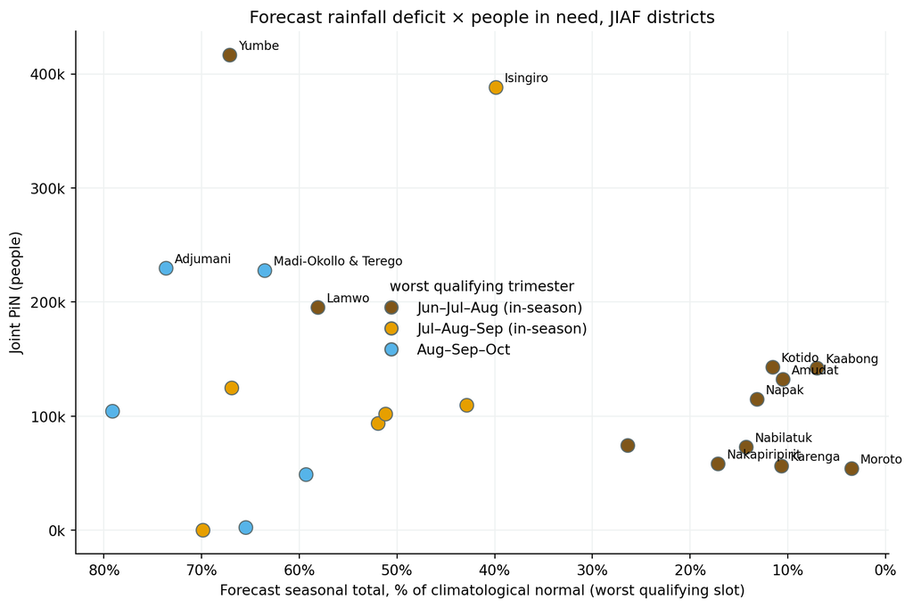

```python
s = comb[comb["joint_pin"].notna() & comb["pct_normal"].notna()].copy()
TRI_COLORS = {"Jun–Jul–Aug": "#7f5619", "Jul–Aug–Sep": "#e69f00", "Aug–Sep–Oct": "#56b4e9"}
s["color"] = s["tri_label"].map(TRI_COLORS).fillna("#9db1b3")

fig, ax = plt.subplots(figsize=(9, 6))
ax.scatter(s["pct_normal"], s["joint_pin"], s=90, c=s["color"],
           edgecolor="#5b6b6d", linewidth=0.8, zorder=3)
seen = [t for t in TRI_COLORS if t in set(s["tri_label"])]
ax.legend(handles=[plt.Line2D([], [], marker="o", ls="", markersize=9,
                              markerfacecolor=TRI_COLORS[t], markeredgecolor="#5b6b6d",
                              label=f"{t}{' (in-season)' if t != 'Aug–Sep–Oct' else ''}")
                   for t in seen],
          title="worst qualifying trimester", loc="center",
          bbox_to_anchor=(0.5, 0.45), frameon=False)
for _, r in s.iterrows():
    if r["pct_normal"] <= s["pct_normal"].quantile(0.35) or \
       r["joint_pin"] >= s["joint_pin"].quantile(0.7):
        ax.annotate(r["district"], (r["pct_normal"], r["joint_pin"]),
                    xytext=(6, 4), textcoords="offset points", fontsize=8.5)
ax.set_xlabel("Forecast seasonal total, % of climatological normal (worst qualifying slot)")
ax.set_ylabel("Joint PiN (people)")
ax.xaxis.set_major_formatter(lambda v, _: f"{v:.0f}%")
ax.yaxis.set_major_formatter(lambda v, _: f"{v/1e3:,.0f}k")
ax.invert_xaxis()  # drier to the right, matching "worse →"
ax.grid(color="#eef1f1", zorder=0)
ax.spines[["top", "right"]].set_visible(False)
ax.set_title("Forecast rainfall deficit × people in need, JIAF districts")
plt.tight_layout()
plt.show()
```

## Priorities: where first, what kind, when

Everything above establishes three facts per district: how deep the forecast deficit is, how many people were already in need before the season failed, and whether a response footprint exists there. This section reads those three dimensions together. It adds no new data or model; the grouping is the agro-ecological grouping from the cropping-seasons section, and every number comes from the tables above.

**priority groups**

```python
pri = comb[comb["joint_pin"].notna() & comb["pct_normal"].notna()].copy()
pri = pri.merge(dz[["pcode", "zone"]].drop_duplicates("pcode"), on="pcode", how="left")
pri["group"] = np.select(
    [pri["zone"] == "Karamoja", pri["zone"] == "West Nile"],
    ["Karamoja", "West Nile corridor"], "Bimodal south / west")
pri["coverage"] = pri["targeted"] / pri["joint_pin"]

gs = (pri.groupby("group")
        .agg(districts=("district", "count"), joint_pin=("joint_pin", "sum"),
             targeted=("targeted", "sum"), reached=("reached", "sum"),
             deficit_min=("pct_normal", "min"), deficit_max=("pct_normal", "max"))
        .reindex(["Karamoja", "West Nile corridor", "Bimodal south / west"]))
gs["deficit range"] = gs.apply(lambda r: f"{r['deficit_min']:.0f}-{r['deficit_max']:.0f}% of normal", axis=1)
gs["targeted / PiN"] = gs["targeted"] / gs["joint_pin"]
out_gs = gs[["districts", "joint_pin", "targeted", "reached", "deficit range", "targeted / PiN"]]
out_gs.columns = ["Districts", "Joint PiN", "Targeted", "Reached", "Forecast deficit", "Targeted / PiN"]
(out_gs.style.format({"Joint PiN": "{:,.0f}", "Targeted": "{:,.0f}", "Reached": "{:,.0f}",
                      "Targeted / PiN": "{:.0%}"}, na_rep="none reported"))
```

| group | Districts | Joint PiN | Targeted | Reached | Forecast deficit | Targeted / PiN |
| --- | --- | --- | --- | --- | --- | --- |
| Karamoja | 9 | 847,143 | 92,399 | 102,175 | 3-26% of normal | 11% |
| West Nile corridor | 6 | 1,049,455 | 645,011 | 373,252 | 59-74% of normal | 61% |
| Bimodal south / west | 7 | 992,456 | 835,202 | 511,094 | 40-79% of normal | 84% |

The reading, group by group:

- **Karamoja first.** It has received 41-54% of its normal season-to-date rain, the driest or near-driest Apr-Jul on record, in a pastoral zone where the failed Jun-Aug rains are a pasture, water and livestock crisis, and it is the group where the response footprint is thinnest: six of the nine districts have no reported targeted or reached figures at all, and where figures exist (Kotido, Kaabong, Moroto) they target roughly a tenth of the group’s PiN. Whatever explains that gap (reporting scope or actual absence), it is the first thing to resolve, because the dry season from October gives no pasture regrowth until the next rains around April.
- **West Nile corridor: a near-normal season that must last the year.** The season-to-date accumulation is 84-99% of normal and the record-dry June hit at harvest, after near-normal planting and growth rains; the main season is close to normal in water terms, with risk in harvest conditions and late fields. But this zone has no second season, so this harvest must last until the March 2027 planting. A response exists here but targets well under the JIAF caseload; the question is depth and duration of assistance, not whether to start.
- **Bimodal south / west: a decision window, not yet a verdict.** Second-season planting (Aug-Oct) is at risk of poor establishment in the record-dry Aug-Sep, but the strongly wet Oct-Dec favors whatever does get established. These districts need a check at establishment time rather than an immediate scale-up.

**priority board**

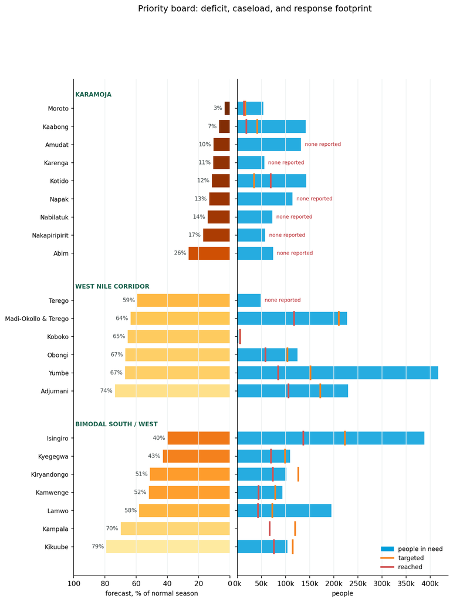

One row per JIAF district, grouped by situation and sorted driest-first. Left: the forecast deficit (darker = less of the normal season’s rain). Right: people in need (blue), with targeted (orange tick) and reached (red tick) from the monitoring workbooks; ‘none reported’ marks districts absent from those workbooks.

```python
import matplotlib.cm as cm
from matplotlib.colors import Normalize as MplNorm

order = ["Karamoja", "West Nile corridor", "Bimodal south / west"]
blocks = [pri[pri["group"] == g].sort_values("pct_normal") for g in order]
gap = 1.6
ys, rows_flat = [], []
y = 0.0
for blk in blocks:
    start = y
    for _, r in blk.iterrows():
        rows_flat.append((y, r)); y += 1
    ys.append((start, y)); y += gap
total_h = y

fig, (axL, axR) = plt.subplots(
    1, 2, figsize=(9.5, 0.42 * total_h + 1.4), sharey=True,
    gridspec_kw={"width_ratios": [1, 1.35], "wspace": 0.04})
cmap, nrm = cm.get_cmap("YlOrBr_r"), MplNorm(0, 100)
for yy, r in rows_flat:
    axL.barh(yy, r["pct_normal"], color=cmap(nrm(r["pct_normal"])), height=0.72)
    axL.text(r["pct_normal"] + 1.5, yy, f"{r['pct_normal']:.0f}%",
             va="center", ha="right", fontsize=8, color="#3f4748")
    axR.barh(yy, r["joint_pin"], color=C_PIN, height=0.72, alpha=0.85)
    if pd.notna(r["targeted"]):
        axR.plot([r["targeted"]] * 2, [yy - 0.36, yy + 0.36], color=C_TGT, lw=2.4)
    if pd.notna(r["reached"]):
        axR.plot([r["reached"]] * 2, [yy - 0.36, yy + 0.36], color=C_REA, lw=2.4)
    if pd.isna(r["targeted"]) and pd.isna(r["reached"]):
        axR.text(r["joint_pin"] + 8000, yy, "none reported", va="center",
                 fontsize=7.2, color="#b8272d")
axL.set_yticks([yy for yy, _ in rows_flat], [r["district"] for _, r in rows_flat], fontsize=8.5)
for (start, end), g in zip(ys, order):
    axL.text(99, start - 0.75, g.upper(), ha="left", va="center",
             fontsize=8.5, fontweight="bold", color="#18614c")
axL.set_xlim(0, 100); axL.invert_xaxis(); axL.invert_yaxis()
axL.set_xlabel("forecast, % of normal season", fontsize=9)
axR.set_xlabel("people", fontsize=9)
axR.xaxis.set_major_formatter(lambda v, _: f"{v/1e3:,.0f}k")
for ax in (axL, axR):
    ax.spines[["top", "right"]].set_visible(False)
    ax.grid(axis="x", color="#eef1f1", zorder=0)
axR.legend(handles=[Patch(color=C_PIN, label="people in need"),
                    plt.Line2D([], [], color=C_TGT, lw=2.4, label="targeted"),
                    plt.Line2D([], [], color=C_REA, lw=2.4, label="reached")],
           loc="lower right", frameon=False, fontsize=8.5)
fig.suptitle("Priority board: deficit, caseload, and response footprint", y=0.995)
plt.tight_layout()
plt.show()
```

**when-to-act timeline**

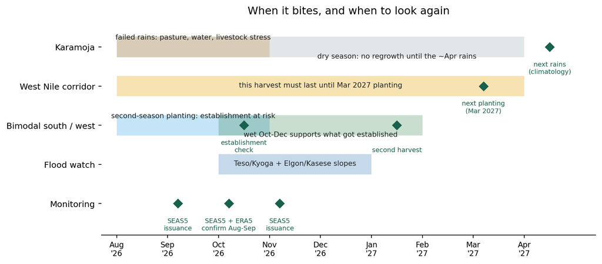

What happens when, from the crop calendars, the ERA5 climatology and the SEAS5 issuance cycle. Diamonds are decision or verification points.

```python
MONTHS = ["Aug", "Sep", "Oct", "Nov", "Dec", "Jan", "Feb", "Mar", "Apr"]
X = {m: i for i, m in enumerate(MONTHS)}

rows = [
    ("Karamoja", [
        (X["Aug"], X["Oct"] + 1, "#7f5619", 0.30, "failed rains: pasture, water, livestock stress"),
        (X["Nov"], X["Mar"] + 1, "#9db1b3", 0.30, "dry season: no regrowth until the ~Apr rains"),
    ], [(X["Apr"] + 0.5, "next rains\n(climatology)")]),
    ("West Nile corridor", [
        (X["Aug"], X["Mar"] + 1, "#e69f00", 0.30, "this harvest must last until Mar 2027 planting"),
    ], [(X["Mar"] + 0.2, "next planting\n(Mar 2027)")]),
    ("Bimodal south / west", [
        (X["Aug"], X["Oct"] + 1, "#56b4e9", 0.35, "second-season planting: establishment at risk"),
        (X["Oct"], X["Jan"] + 1, "#2a7e43", 0.25, "wet Oct-Dec supports what got established"),
    ], [(X["Oct"] + 0.5, "establishment\ncheck"), (X["Jan"] + 0.5, "second harvest")]),
    ("Flood watch", [
        (X["Oct"], X["Dec"] + 1, "#1f69b3", 0.25, "Teso/Kyoga + Elgon/Kasese slopes"),
    ], []),
    ("Monitoring", [], [
        (X["Sep"] + 0.2, "SEAS5\nissuance"), (X["Oct"] + 0.2, "SEAS5 + ERA5\nconfirm Aug-Sep"),
        (X["Nov"] + 0.2, "SEAS5\nissuance"),
    ]),
]

fig, ax = plt.subplots(figsize=(9.5, 4.2))
for i, (name, bands, marks) in enumerate(rows):
    yy = len(rows) - 1 - i
    for k, (x0, x1, c, a, lab) in enumerate(bands):
        ax.barh(yy, x1 - x0, left=x0, height=0.52, color=c, alpha=a)
        dy = 0.24 if (len(bands) > 1 and k == 0) else (-0.24 if len(bands) > 1 else 0.02)
        ax.text((x0 + x1) / 2, yy + dy, lab, ha="center", va="center", fontsize=8, color="#1f2324")
    for x, lab in marks:
        ax.plot(x, yy, marker="D", ms=7, color="#18614c")
        ax.annotate(lab, (x, yy), xytext=(0, -30), textcoords="offset points",
                    ha="center", fontsize=7.3, color="#18614c")
ax.set_yticks(range(len(rows)), [r[0] for r in rows][::-1], fontsize=9.5)
ax.set_xticks(range(len(MONTHS)), [f"{m}\n'26" if i < 5 else f"{m}\n'27" for i, m in enumerate(MONTHS)], fontsize=8.5)
ax.set_xlim(-0.3, len(MONTHS) + 0.4); ax.set_ylim(-0.8, len(rows) - 0.3)
ax.spines[["top", "right", "left"]].set_visible(False)
ax.set_title("When it bites, and when to look again")
plt.tight_layout()
plt.show()
```

The monitoring row is the workload plan for this analysis itself: SEAS5 issues around the 5th of each month, so the September and October issuances (and the ERA5 observations that confirm how Aug-Sep actually landed) are the natural points to re-run this document and re-check the bimodal establishment window. The pipeline is parameterized, so re-running just means re-rendering the document.

## Flood outlook: the OND wet season

### When and where OND flooding recurs

The same issuance that forecasts the drought puts October, November and December at the 91st-98th wet percentile, so the flood question is part of the outlook. Worth knowing before the map: Oct-Dec is not Uganda’s main flood season everywhere. In the FloodScan record (daily SFED, 1998-2026) the national annual flood peak falls in April or May in 19 of 29 years, driven by the Northern (April peak) and Eastern (May peak) regions; November is a genuine secondary peak in the Central and Western regions. The map below shows OND because that is the window the current forecast puts wet, not because it is the only season that floods.

**monthly flood cycle by region**

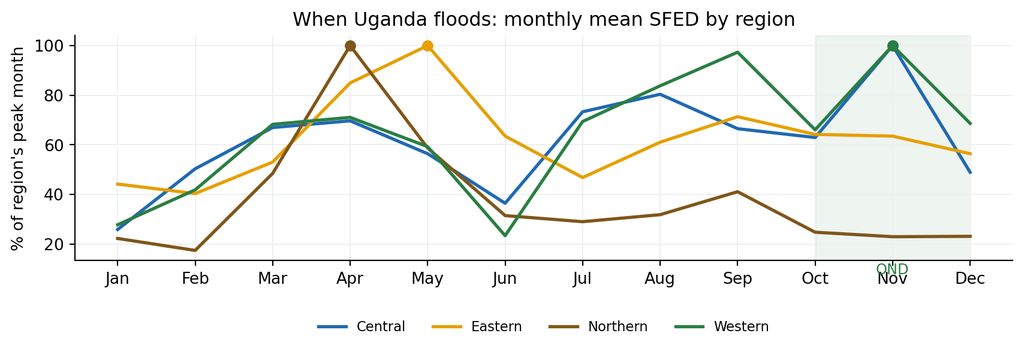

Seasonal cycle of flooding: monthly mean FloodScan SFED per region, 1998-2026, scaled to each region’s peak month. April-May dominates the north and east; November is the Central/Western secondary peak.

```python
fs1 = pd.read_sql("SELECT pcode, valid_date, mean FROM public.floodscan "
                  "WHERE iso3='UGA' AND adm_level=1 AND band='SFED'",
                  engine, parse_dates=["valid_date"])
cyc = (fs1.assign(mo=fs1["valid_date"].dt.month)
          .groupby(["pcode", "mo"])["mean"].mean().unstack())
cyc = 100 * cyc.div(cyc.max(axis=1), axis=0)
names1 = dict(zip(cod1["ADM1_PCODE"], cod1["ADM1_EN"]))
fig, ax = plt.subplots(figsize=(9, 3.4))
RC = {"UG1": "#1f69b3", "UG2": "#e69f00", "UG3": "#7f5619", "UG4": "#2a7e43"}
for pc, row in cyc.iterrows():
    ax.plot(row.index, row.values, color=RC[pc], lw=2, label=names1[pc])
    pk = row.idxmax()
    ax.plot(pk, row[pk], marker="o", ms=6, color=RC[pc])
ax.axvspan(10, 12, color="#2a7e43", alpha=0.08)
ax.text(11, 8, "OND", ha="center", fontsize=9, color="#2a7e43")
ax.set_xticks(range(1, 13), [calendar.month_abbr[m] for m in range(1, 13)])
ax.set_ylabel("% of region's peak month")
ax.legend(frameon=False, fontsize=8.5, ncol=4, loc="lower center", bbox_to_anchor=(0.5, -0.38))
ax.grid(color="#eef1f1", zorder=0)
ax.spines[["top", "right"]].set_visible(False)
ax.set_title("When Uganda floods: monthly mean SFED by region")
plt.tight_layout()
plt.show()
```

**OND flood recurrence map**

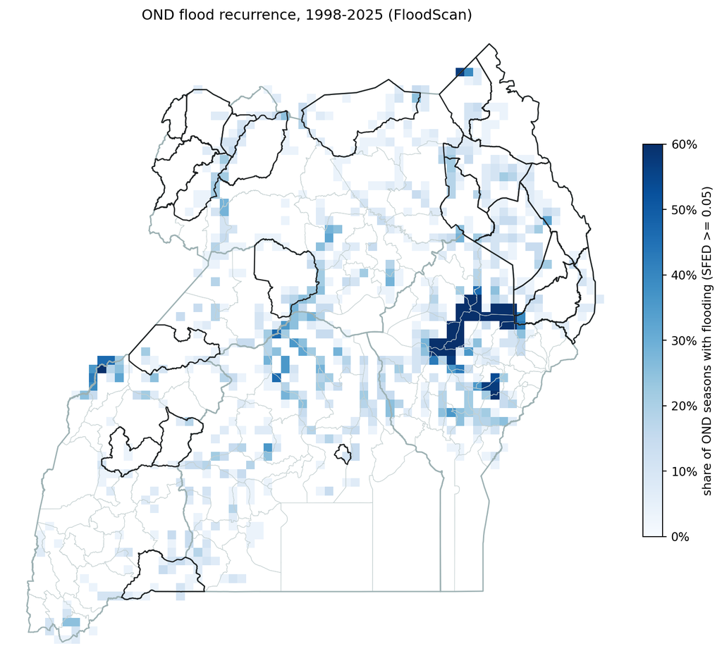

Share of Oct-Dec seasons 1998-2025 with any meaningful flooding (seasonal max SFED >= 0.05, the team’s noise floor), per ~9 km FloodScan pixel. Black outline: JIAF districts. Persistent wetland systems (Lake Kyoga fringes in Teso) recur most; this is historical recurrence, not a forecast.

```python
import rasterio as rio
from rasterio.io import MemoryFile
tif = stratus.load_blob_data(f"{UGA_DIR}/flood_ond_recurrence.tif", stage="dev")
from rasterio.features import geometry_mask
with MemoryFile(tif) as mf, mf.open() as ds:
    rec = ds.read(1)
    ext = [ds.bounds.left, ds.bounds.right, ds.bounds.bottom, ds.bounds.top]
    inside = geometry_mask(cod1.geometry, out_shape=rec.shape,
                           transform=ds.transform, invert=True, all_touched=True)
fig, ax = plt.subplots(figsize=(9, 8))
masked = np.ma.masked_where(~inside | (rec < 0.02), rec)
im = ax.imshow(masked, extent=ext, cmap="Blues", vmin=0, vmax=0.6, zorder=2)
cod2.boundary.plot(ax=ax, color=C_EDGE, linewidth=0.4, zorder=3)
cod1.boundary.plot(ax=ax, color="#9db1b3", linewidth=1.1, zorder=3)
cod2[cod2["ADM2_PCODE"].isin(jiaf_pcodes)].boundary.plot(ax=ax, color="#1d2021", linewidth=1.0, zorder=4)
ax.set_xlim(29.4, 35.1); ax.set_ylim(-1.6, 4.4)
cb = plt.colorbar(im, ax=ax, shrink=0.6)
cb.set_label("share of OND seasons with flooding (SFED >= 0.05)")
cb.ax.yaxis.set_major_formatter(lambda v, _: f"{100*v:.0f}%")
ax.set_axis_off()
ax.set_title("OND flood recurrence, 1998-2025 (FloodScan)")
plt.tight_layout()
plt.show()
```

**highest-recurrence districts**

```python
fl = stratus.load_parquet_from_blob(f"{UGA_DIR}/flood_ond_adm2.parquet", stage="dev")
fl = fl.merge(cod2[["ADM2_PCODE", "ADM2_EN"]], left_on="pcode", right_on="ADM2_PCODE")
top = fl.nlargest(12, "recurrence_any")[["ADM2_EN", "recurrence_any", "recurrence_substantial"]]
top.columns = ["District", "Any flooding (share of OND seasons)", "Substantial (SFED >= 0.2)"]
(top.style.hide(axis="index")
    .format({"Any flooding (share of OND seasons)": "{:.0%}", "Substantial (SFED >= 0.2)": "{:.0%}"})
    .set_caption("The 12 most flood-recurrent of Uganda's 135 districts, ranked by "
                 "pixel-mean OND flood recurrence, 1998-2025. Selected on the flood metric "
                 "alone, country-wide; none is in the JIAF set (see the note below the map)."))
```

Table 3: The 12 most flood-recurrent of Uganda's 135 districts, ranked by pixel-mean OND flood recurrence, 1998-2025. Selected on the flood metric alone, country-wide; none is in the JIAF set (see the note below the map).

| District | Any flooding (share of OND seasons) | Substantial (SFED >= 0.2) |
| --- | --- | --- |
| Ngora | 58% | 26% |
| Pallisa | 32% | 11% |
| Kumi | 30% | 22% |
| Butaleja | 24% | 3% |
| Katakwi | 23% | 10% |
| Soroti | 20% | 7% |
| Serere | 20% | 5% |
| Budaka | 19% | 5% |
| Bukedea | 16% | 10% |
| Ntoroko | 14% | 5% |
| Tororo | 13% | 1% |
| Bulambuli | 12% | 2% |

### Extreme seasons: the El Niño / IOD lens

The 2026 OND season arrives with a strong El Niño and a positive Indian Ocean Dipole crossing its event threshold (weekly DMI +0.41 in early August, forecast to stay positive through December; [BOM](https://www.bom.gov.au/climate/iod/), [WMO](https://wmo.int/resources/publication-series/global-seasonal-climate-update/gscu-aso2026)). What did past seasons like that look like? The panels below show every El Niño OND in the FloodScan record (OND-mean ONI ≥ +0.5, the standard cut: nine seasons) plus 2025, each labeled with its observed OND-mean ONI (ENSO) and DMI (IOD) from NOAA (`pipeline/fetch_climate_indices.py`), its flooded area, and that area’s empirical return period.

**extreme-year facet maps**

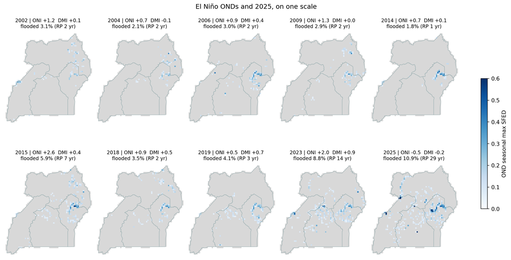

OND seasonal-max SFED in every El Niño OND of the record (OND-mean ONI >= +0.5) plus 2025, against the same color scale. Panel labels give the observed OND-mean ENSO (ONI) and IOD (DMI) indices, the flooded share of pixels (SFED >= 0.05), and its rank-based return period among the 28 seasons.

```python
from scipy.stats import spearmanr
ytif = stratus.load_blob_data(f"{UGA_DIR}/flood_ond_yearly_max.tif", stage="dev")
with MemoryFile(ytif) as mf, mf.open() as yds:
    yyears = [int(d) for d in yds.descriptions]
    ystack = yds.read()
    yext = [yds.bounds.left, yds.bounds.right, yds.bounds.bottom, yds.bounds.top]
    yin = geometry_mask(cod1.geometry, out_shape=ystack.shape[1:], transform=yds.transform, invert=True, all_touched=True)
idxs = stratus.load_parquet_from_blob(f"{PROJECT_PREFIX}/raw/climate_indices/ond_indices.parquet", stage="dev").set_index("year")
area_pct = pd.Series({y: 100 * np.nanmean((ystack[i] >= 0.05)[yin]) for i, y in enumerate(yyears)})
area_rank = area_pct.rank(ascending=False)
area_rp = (len(area_pct) + 1) / area_rank

nino_years = sorted(int(y) for y in idxs.index
                    if 1998 <= y <= 2025 and idxs.loc[y, "oni_ond"] >= 0.5)
FACET_YEARS = nino_years + [2025]   # 2025 is not an El Niño OND; shown for scale
fig, axes = plt.subplots(2, 5, figsize=(13, 7.0), layout="constrained")
if len(FACET_YEARS) > axes.size:   # zip would silently drop panels
    raise ValueError(f"{len(FACET_YEARS)} facet years > {axes.size} panels — resize the grid")
for ax in axes.flat[len(FACET_YEARS):]:
    ax.set_visible(False)
for ax, yr in zip(axes.flat, FACET_YEARS):
    arr = ystack[yyears.index(yr)]
    m = np.ma.masked_where(~yin | (arr < 0.05), arr)
    ax.imshow(np.where(yin, 0, np.nan), extent=yext, cmap="Greys", vmin=-1, vmax=3)
    im = ax.imshow(m, extent=yext, cmap="Blues", vmin=0, vmax=0.6)
    cod1.boundary.plot(ax=ax, color="#9db1b3", linewidth=0.6)
    ax.set_xlim(29.4, 35.1); ax.set_ylim(-1.6, 4.4); ax.set_axis_off()
    ax.set_title(f"{yr} | ONI {idxs.loc[yr,'oni_ond']:+.1f}  DMI {idxs.loc[yr,'dmi_ond']:+.1f}\n"
                 f"flooded {area_pct[yr]:.1f}% (RP {area_rp[yr]:.0f} yr)", fontsize=9)
fig.colorbar(im, ax=axes, shrink=0.5, label="OND seasonal max SFED")
fig.suptitle("El Niño ONDs and 2025, on one scale", fontsize=12)
plt.show()
```

**NoteWhat the statistics support, and what is our interpretation**

With 28 seasons, be explicit about which links are demonstrated and which are a reading of the record.

**Statistically supported** (Spearman unless noted): the ocean drivers set the season’s *rainfall* (OND rain vs DMI r = +0.63, p < 0.001; vs ONI r = +0.55, p = 0.002), and the wettest-quintile ONDs have larger flooded areas than the rest (Mann-Whitney one-sided p = 0.018).

**Suggestive but not established**: the continuous rain-to-flooded-area relationship (r = +0.28, p = 0.14) and season-to-season persistence of flooded area (lag-1 r = +0.38, p = 0.053).

**Not supported as direct links**: neither index predicts flooded area directly (area vs DMI r = +0.17, p = 0.40; vs ONI r = +0.31, p = 0.11). In plain terms: if the ocean drivers matter for flooding here, the data say they matter only by making the season wetter; there is no sign of an additional index-to-flood pathway beyond rainfall.

**Interpretation, not tested**: the pattern that El Niño years flood more when a positive IOD co-occurs. Group cuts: El Niño = OND-mean ONI ≥ +0.5, +IOD = OND-mean DMI ≥ +0.4. Descriptively, the four El Niño + IOD seasons (2006, 2018, 2019, 2023) averaged 4.9% flooded (median 3.8%) against 3.2% (median 2.9%) in the five El Niño-only seasons (2002, 2004, 2009, 2014, 2015). The split is sensitive to the DMI cut: 2015 (DMI +0.37, flooded 5.9%) sits a hair below it in the El Niño-only group, and moving that one borderline year across strengthens the contrast to 5.1% vs 2.5% (means) - so the lean survives the cut, but the biggest floods of all (2024, 2025) still sit in the neither-driver group. Read it as a lean, not a rule.

**Also interpretation, on why 2025 flooded on little rain**: two candidate mechanisms, neither measured here. *Antecedent wetness*: 2023-24 were the second- and third-largest flood ONDs, so the system entered 2025 wet. *Regulation and channel state*: Lake Victoria’s only outlet is the managed release at Jinja (Nalubaale/Kiira, then Bujagali-Isimba-Kyoga), release policy has been publicly blamed for downstream flooding in earlier high-stand years, and papyrus “floating islands” have blocked the Kyoga outlet before ([Monitor](https://www.monitor.co.ug/uganda/news/national/floods-blamed-on-uganda-s-policy-on-releasing-l-victoria-water-1891212), [EACCR](http://www.eaccr.org/rising-water-levels-lake-victoria-and-nile-system-uganda)). One spatial clue from our own data: only 18% of 2025’s flooded pixels lie in the recurrent Kyoga/wetland core, defined here as pixels that flood in at least 30% of ONDs 1998-2025 (`recurrence_any` ≥ 0.3 on the recurrence raster); for 2019 the same figure is 40%. The 2023-25 floods spread far beyond the lake system, which fits broad antecedent wetness better than a purely lake-stage or dam-release story, without excluding either as a contributor. Settling this needs lake-level and discharge data we have not used.

**rainfall vs flooded area, with drivers**

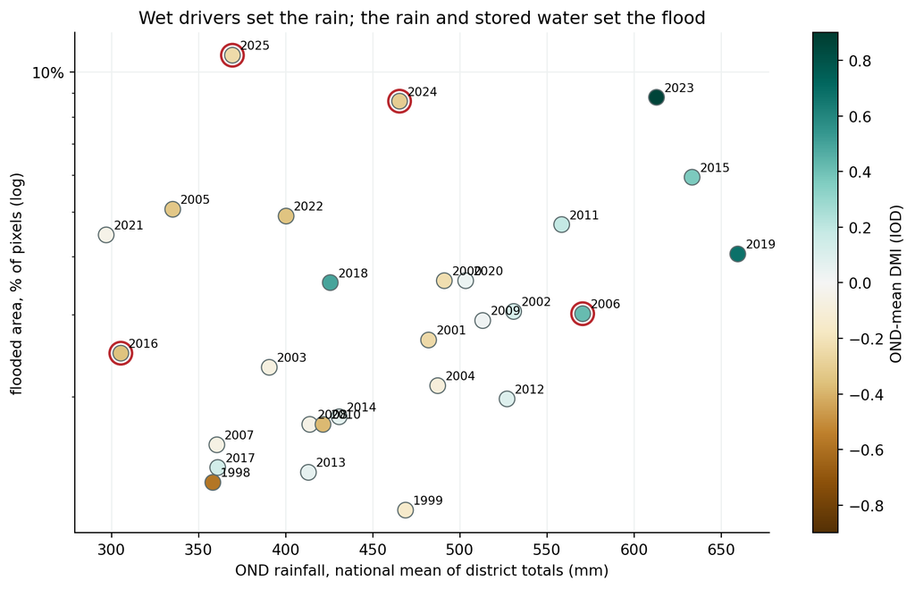

Each point is one OND season: national mean OND rainfall (x) against flooded area (y, log scale). Fill color: the observed IOD (DMI). Ringed points followed a top-5 flood season. n=28; the callout above says which of these relationships are statistically supported and which are interpretation.

```python
ond_rain = (e_all[e_all["mo"].isin([10, 11, 12])]
            .groupby(["yr", "pcode"])["mm"].sum().groupby("yr").mean().loc[1998:2025])
drv = pd.DataFrame({"rain": ond_rain, "area": area_pct, "dmi": idxs["dmi_ond"], "oni": idxs["oni_ond"]}).dropna()
top5 = set(area_pct.nlargest(5).index)
fig, ax = plt.subplots(figsize=(9, 5.6))
sc = ax.scatter(drv["rain"], drv["area"], c=drv["dmi"], cmap="BrBG", vmin=-0.9, vmax=0.9,
                s=110, edgecolor="#5b6b6d", linewidth=0.8, zorder=3)
for yr, r in drv.iterrows():
    if (yr - 1) in top5:
        ax.scatter(r["rain"], r["area"], s=230, facecolor="none", edgecolor="#b8272d", linewidth=1.6, zorder=2)
    ax.annotate(str(yr), (r["rain"], r["area"]), xytext=(5, 4), textcoords="offset points", fontsize=8)
ax.set_yscale("log")
ax.set_xlabel("OND rainfall, national mean of district totals (mm)")
ax.set_ylabel("flooded area, % of pixels (log)")
ax.yaxis.set_major_formatter(lambda v, _: f"{v:g}%")
cb = plt.colorbar(sc, ax=ax); cb.set_label("OND-mean DMI (IOD)")
ax.grid(color="#eef1f1", zorder=0)
ax.spines[["top", "right"]].set_visible(False)
ax.set_title("Wet drivers set the rain; the rain and stored water set the flood")
plt.tight_layout()
plt.show()
```